# Manipulation of NGS data with Bioconductor : Genomic Ranges library

Greg VOISIN

Wednesday, March 18, 2015

# Manipulation of IRanges and GenomicRanges R objects:

## load library

```r
library(IRanges)
library(GenomicRanges)
library(GenomicFeatures)
library(rtracklayer)
```

## Illumina annotation

```r
library(FDb.InfiniumMethylation.hg19)
#acces to the data
infiniumMethylation <- features(FDb.InfiniumMethylation.hg19)
univers <- names(infiniumMethylation)

#object class
class(infiniumMethylation)
```

```
## [1] "GRanges"
## attr(,"package")
## [1] "GenomicRanges"
```

```r
#acces a one element
infiniumMethylation["cg00000029"]
```

```
## GRanges with 1 range and 14 metadata columns:
##              seqnames               ranges strand | addressA_450
##                 <Rle>            <IRanges>  <Rle> |  <character>
##   cg00000029    chr16 [53468112, 53468113]      - |     14782418
##              addressB_450 addressA_27 addressB_27  channel450   channel27
##               <character> <character> <character> <character> <character>
##   cg00000029                     <NA>        <NA>        Both        <NA>
##                probeType   percentGC    platform
##              <character> <character> <character>
##   cg00000029          cg        0.46       HM450
##                                                       sourceSeq
##                                                     <character>
##   cg00000029 GCTGTACTGACGAGAAAATGTCCAAAAGACACTGACGTGTGAAGGTTTCG
##               probeStart    probeEnd probeTarget probeExtension
##              <character> <character> <character>    <character>
##   cg00000029    53468112    53468161    53468112           <NA>
##   ---
##   seqlengths:
##    chr16  chr3  chr1  chr8 chr14 chr15 ... chr22  chrX chr13  chr5  chrY
##       NA    NA    NA    NA    NA    NA ...    NA    NA    NA    NA    NA
```

```r
# acces au chr
as.vector(seqnames(infiniumMethylation["cg00000029"]))
```

```
## [1] "chr16"
```

```r
# acces coord.
X= ranges(infiniumMethylation["cg00000029"])
start(X)
```

```
## [1] 53468112
```

```r
end(X)
```

```
## [1] 53468113
```

# Annotation hub:

```r
library(AnnotationHub)
ah = AnnotationHub()

ensGene = ah$goldenpath.hg19.database.ensGene_0.0.1.RData
ensGene
```

```
## UCSC track 'ensGene'
## UCSCData with 204940 ranges and 5 metadata columns:
##                         seqnames               ranges strand   |
##                            <Rle>            <IRanges>  <Rle>   |
##        [1]                  chr1 [66999066, 67210057]      +   |
##        [2]                  chr1 [66999275, 67210768]      +   |
##        [3]                  chr1 [66999298, 67145425]      +   |
##        [4]                  chr1 [66999823, 67208882]      +   |
##        [5]                  chr1 [66999839, 67142779]      +   |
##        ...                   ...                  ...    ... ...
##   [204936] chr19_gl000209_random     [ 57208,  68122]      +   |
##   [204937] chr19_gl000209_random     [ 70097,  84658]      +   |
##   [204938] chr19_gl000209_random     [ 86746,  96246]      +   |
##   [204939] chr19_gl000209_random     [147649, 156298]      +   |
##   [204940] chr19_gl000209_random     [147649, 156325]      +   |
##                       name     score     itemRgb                thick
##                <character> <numeric> <character>            <IRanges>
##        [1] ENST00000237247         0        <NA> [67000042, 67208778]
##        [2] ENST00000371039         0        <NA> [67000042, 67208778]
##        [3] ENST00000424320         0        <NA> [67000042, 67145425]
##        [4] ENST00000371035         0        <NA> [67000042, 67208778]
##        [5] ENST00000468286         0        <NA> [67142780, 67142779]
##        ...             ...       ...         ...                  ...
##   [204936] ENST00000400854         0        <NA>     [ 57249,  67717]
##   [204937] ENST00000400848         0        <NA>     [ 70108,  83979]
##   [204938] ENST00000400846         0        <NA>     [ 86746,  95742]
##   [204939] ENST00000400827         0        <NA>     [147649, 153110]
##   [204940] ENST00000400829         0        <NA>     [147649, 156325]
##                                                      blocks
##                                               <IRangesList>
##        [1] [    1,    25] [  864,   986] [92465, 92528] ...
##        [2] [    1,    81] [  655,   777] [92256, 92319] ...
##        [3] [    1,    58] [  632,   754] [92233, 92296] ...
##        [4] [    1,   229] [91708, 91771] [98931, 98955] ...
##        [5] [    1,   213] [91692, 91755] [98915, 98939] ...
##        ...                                              ...
##   [204936]       [   1,   81] [ 281,  316] [1183, 1467] ...
##   [204937]       [   1,   45] [1045, 1080] [1825, 2109] ...
##   [204938]       [   1,   34] [ 768,  803] [1566, 1850] ...
##   [204939]       [   1,   34] [ 764,  799] [3291, 3590] ...
##   [204940]       [   1,   34] [ 764,  799] [1542, 1826] ...
##   ---
##   seqlengths:
##                     chr1                  chr2 ... chr18_gl000207_random
##                249250621             243199373 ...                  4262
```

# findOverlaps function

```r
mask= seqnames(ensGene)== "chr1"
ensGene_chr1= ensGene[mask]

ov = findOverlaps(infiniumMethylation, ensGene_chr1)
head(ov)
```

```
## Hits of length 6
## queryLength: 487173
## subjectLength: 17531
##   queryHits subjectHits
##    <integer>   <integer>
##  1         9        2897
##  2        21         645
##  3        21         646
##  4        21         647
##  5        21         648
##  6        21        3929
```

```r
infiniumMethylation[head(queryHits(ov))]
```

```
## GRanges with 6 ranges and 14 metadata columns:
##              seqnames                 ranges strand | addressA_450
##                 <Rle>              <IRanges>  <Rle> |  <character>
##   cg00000363     chr1 [230560793, 230560794]      - |     16661505
##   cg00000957     chr1 [  5937253,   5937254]      - |     65648367
##   cg00000957     chr1 [  5937253,   5937254]      - |     65648367
##   cg00000957     chr1 [  5937253,   5937254]      - |     65648367
##   cg00000957     chr1 [  5937253,   5937254]      - |     65648367
##   cg00000957     chr1 [  5937253,   5937254]      - |     65648367
##              addressB_450 addressA_27 addressB_27  channel450   channel27
##               <character> <character> <character> <character> <character>
##   cg00000363                     <NA>        <NA>        Both        <NA>
##   cg00000957     36743439        <NA>        <NA>         Grn        <NA>
##   cg00000957     36743439        <NA>        <NA>         Grn        <NA>
##   cg00000957     36743439        <NA>        <NA>         Grn        <NA>
##   cg00000957     36743439        <NA>        <NA>         Grn        <NA>
##   cg00000957     36743439        <NA>        <NA>         Grn        <NA>
##                probeType   percentGC    platform
##              <character> <character> <character>
##   cg00000363          cg        0.42       HM450
##   cg00000957          cg         0.7       HM450
##   cg00000957          cg         0.7       HM450
##   cg00000957          cg         0.7       HM450
##   cg00000957          cg         0.7       HM450
##   cg00000957          cg         0.7       HM450
##                                                       sourceSeq
##                                                     <character>
##   cg00000363 TCTTGACTTGGCTTAGTTTTCTCCTTAATCTGAGAAACTTTCCCTGTCCG
##   cg00000957 ATGCTACTGACCCATGCCCGGCAGGGCAAGGGGCCCCAGGACGTCAGCCG
##   cg00000957 ATGCTACTGACCCATGCCCGGCAGGGCAAGGGGCCCCAGGACGTCAGCCG
##   cg00000957 ATGCTACTGACCCATGCCCGGCAGGGCAAGGGGCCCCAGGACGTCAGCCG
##   cg00000957 ATGCTACTGACCCATGCCCGGCAGGGCAAGGGGCCCCAGGACGTCAGCCG
##   cg00000957 ATGCTACTGACCCATGCCCGGCAGGGCAAGGGGCCCCAGGACGTCAGCCG
##               probeStart    probeEnd probeTarget probeExtension
##              <character> <character> <character>    <character>
##   cg00000363   230560793   230560842   230560793           <NA>
##   cg00000957     5937253     5937302     5937253           <NA>
##   cg00000957     5937253     5937302     5937253           <NA>
##   cg00000957     5937253     5937302     5937253           <NA>
##   cg00000957     5937253     5937302     5937253           <NA>
##   cg00000957     5937253     5937302     5937253           <NA>
##   ---
##   seqlengths:
##    chr16  chr3  chr1  chr8 chr14 chr15 ... chr22  chrX chr13  chr5  chrY
##       NA    NA    NA    NA    NA    NA ...    NA    NA    NA    NA    NA
```

```r
ensGene_chr1[head(subjectHits(ov))]
```

```
## UCSC track 'ensGene'
## UCSCData with 6 ranges and 5 metadata columns:
##       seqnames                 ranges strand |            name     score
##          <Rle>              <IRanges>  <Rle> |     <character> <numeric>
##   [1]     chr1 [230457392, 230561475]      - | ENST00000391860         0
##   [2]     chr1 [  5922871,   6052484]      - | ENST00000478423         0
##   [3]     chr1 [  5922873,   6052533]      - | ENST00000489180         0
##   [4]     chr1 [  5922878,   6052531]      - | ENST00000378156         0
##   [5]     chr1 [  5923325,   6052507]      - | ENST00000378169         0
##   [6]     chr1 [  5934965,   5937526]      - | ENST00000506941         0
##           itemRgb                  thick
##       <character>              <IRanges>
##   [1]        <NA> [230459171, 230493053]
##   [2]        <NA> [  6052485,   6052484]
##   [3]        <NA> [  5939565,   6046349]
##   [4]        <NA> [  5923325,   6046349]
##   [5]        <NA> [  6008196,   6046349]
##   [6]        <NA> [  5937527,   5937526]
##                                                 blocks
##                                          <IRangesList>
##   [1] [    1,  1975] [ 3665,  3770] [11199, 11396] ...
##   [2]       [   1,  595] [1080, 1223] [1528, 1707] ...
##   [3]       [   1,  593] [1078, 1221] [1526, 1705] ...
##   [4]       [   1,  588] [1073, 1216] [1521, 1700] ...
##   [5]       [   1,  141] [ 626,  769] [1074, 1253] ...
##   [6]                        [   1,  196] [2189, 2562]
##   ---
##   seqlengths:
##                     chr1                  chr2 ... chr18_gl000207_random
##                249250621             243199373 ...                  4262
```

## IRanges instance

Indicates the start and end positions of 7 genes.

```r
ir <- IRanges(start=c(7, 9, 12, 14, 22:24),end=c(15, 11, 12, 18, 26, 27, 28))
ir
```

```
## IRanges of length 7
##     start end width
## [1]     7  15     9
## [2]     9  11     3
## [3]    12  12     1
## [4]    14  18     5
## [5]    22  26     5
## [6]    23  27     5
## [7]    24  28     5
```

Some methods are available to manipulate the IRanges objects: - intra-range methods: flank, narrow, reflect, resize,restrict, and shift, among others

```r
shift(ir, 5)
```

```
## IRanges of length 7
##     start end width
## [1]    12  20     9
## [2]    14  16     3
## [3]    17  17     1
## [4]    19  23     5
## [5]    27  31     5
## [6]    28  32     5
## [7]    29  33     5
```

- inter-range methods : disjoin, reduce, gaps, and range.

```r
reduce(ir)
```

```
## IRanges of length 2
##     start end width
## [1]     7  18    12
## [2]    22  28     7
```

```r
coverage(ir)
```

```
## integer-Rle of length 28 with 12 runs
##   Lengths: 6 2 4 1 2 3 3 1 1 3 1 1
##   Values : 0 1 2 1 2 1 0 1 2 3 2 1
```

- between range methods: intersect, setdiff, union, pintersect, psetdiff, and punion.

## GenomicsRanges instance

```r
genes <- GRanges(  seqnames=Rle(c("Chr1", "X"), c(1,1)),
                   ranges=IRanges(start=c(19967117, 18962306), end=c(19973212, 18962925)),
                   strand=Rle(c("+", "-"),c(1,1)),
                   seqlengths=c("Chr1"=27905053L, "X"=22422827L)
                )
```

Remarks:  
- GRanges object includes IRanges object.  
- note the L in seqlengths args, which simply guarantees that a number which could be interpreted as 1 byte will always be interpreted as 4 bytes (signed as Long).  
- the minimal information for GRanges object is seqnames, ranges and strand. - Rle object : Run Length Encoding is a common compression technique for storing long sequences with lengthy repeat)

Some methods are available to manipulate the GenomicRanges objects:  
- inspection and accessor

```r
  genes
```

```
## GRanges with 2 ranges and 0 metadata columns:
##       seqnames               ranges strand
##          <Rle>            <IRanges>  <Rle>
##   [1]     Chr1 [19967117, 19973212]      +
##   [2]        X [18962306, 18962925]      -
##   ---
##   seqlengths:
##        Chr1        X
##    27905053 22422827
```

```r
  class(genes)
```

```
## [1] "GRanges"
## attr(,"package")
## [1] "GenomicRanges"
```

```r
  genes[2]
```

```
## GRanges with 1 range and 0 metadata columns:
##       seqnames               ranges strand
##          <Rle>            <IRanges>  <Rle>
##   [1]        X [18962306, 18962925]      -
##   ---
##   seqlengths:
##        Chr1        X
##    27905053 22422827
```

```r
  strand(genes)
```

```
## factor-Rle of length 2 with 2 runs
##   Lengths: 1 1
##   Values : + -
## Levels(3): + - *
```

```r
  width(genes)
```

```
## [1] 6096  620
```

```r
  length(genes)
```

```
## [1] 2
```

- add informations : names for each genes.

```r
names(genes) <- c("FBgn0039155", "FBgn0085359")
genes
```

```
## GRanges with 2 ranges and 0 metadata columns:
##               seqnames               ranges strand
##                  <Rle>            <IRanges>  <Rle>
##   FBgn0039155     Chr1 [19967117, 19973212]      +
##   FBgn0085359        X [18962306, 18962925]      -
##   ---
##   seqlengths:
##        Chr1        X
##    27905053 22422827
```

- optional informations for the genes: META columns.

```r
genes
```

```
## GRanges with 2 ranges and 0 metadata columns:
##               seqnames               ranges strand
##                  <Rle>            <IRanges>  <Rle>
##   FBgn0039155     Chr1 [19967117, 19973212]      +
##   FBgn0085359        X [18962306, 18962925]      -
##   ---
##   seqlengths:
##        Chr1        X
##    27905053 22422827
```

```r
mcols(genes) <- DataFrame(EntrezId=c("42865", "2768869"), Symbol=c("kal-1", "CG34330"))
genes
```

```
## GRanges with 2 ranges and 2 metadata columns:
##               seqnames               ranges strand |    EntrezId
##                  <Rle>            <IRanges>  <Rle> | <character>
##   FBgn0039155     Chr1 [19967117, 19973212]      + |       42865
##   FBgn0085359        X [18962306, 18962925]      - |     2768869
##                    Symbol
##               <character>
##   FBgn0039155       kal-1
##   FBgn0085359     CG34330
##   ---
##   seqlengths:
##        Chr1        X
##    27905053 22422827
```

## GRangesList instance

GRangesList represents a more complexe structure and used for sliced transcripts, all genes of the genome with the exon composition, …

```r
gr1 <- GRanges(seqnames = "chr2", ranges = IRanges(3, 6), strand = "+", score = 5L, GC = 0.45)
gr2 <- GRanges(seqnames = c("chr1", "chr1"), ranges = IRanges(c(7,13), width = 3), strand = c("+", "-"), score = 3:4, GC = c(0.3, 0.5))
grlist <- GRangesList("txA" = gr1, "txB" = gr2)
grlist
```

```
## GRangesList of length 2:
## $txA
## GRanges with 1 range and 2 metadata columns:
##       seqnames    ranges strand |     score        GC
##          <Rle> <IRanges>  <Rle> | <integer> <numeric>
##   [1]     chr2    [3, 6]      + |         5      0.45
##
## $txB
## GRanges with 2 ranges and 2 metadata columns:
##       seqnames   ranges strand | score  GC
##   [1]     chr1 [ 7,  9]      + |     3 0.3
##   [2]     chr1 [13, 15]      - |     4 0.5
##
## ---
## seqlengths:
##  chr2 chr1
##    NA   NA
```

Why is interesting to work with a list ? In practice, the mclapply allows to parallize the job on a cluster, from a list object.

# Manipulate a big GRange object

## import a gff file

```r
gff <- import.gff("DATA/gff3.gff", asRangedData=FALSE)
gff
```

```
## GRanges with 449 ranges and 5 metadata columns:
##         seqnames           ranges strand   |   source       type     score
##            <Rle>        <IRanges>  <Rle>   | <factor>   <factor> <numeric>
##     [1]     Chr1 [   1, 30427671]      +   |   TAIR10 chromosome      <NA>
##     [2]     Chr1 [3631,     5899]      +   |   TAIR10       gene      <NA>
##     [3]     Chr1 [3631,     5899]      +   |   TAIR10       mRNA      <NA>
##     [4]     Chr1 [3760,     5630]      +   |   TAIR10    protein      <NA>
##     [5]     Chr1 [3631,     3913]      +   |   TAIR10       exon      <NA>
##     ...      ...              ...    ... ...      ...        ...       ...
##   [445]     ChrM   [11918, 12241]      +   |   TAIR10       gene      <NA>
##   [446]     ChrM   [11918, 12241]      +   |   TAIR10       mRNA      <NA>
##   [447]     ChrM   [11918, 12241]      +   |   TAIR10    protein      <NA>
##   [448]     ChrM   [11918, 12241]      +   |   TAIR10       exon      <NA>
##   [449]     ChrM   [11918, 12241]      +   |   TAIR10        CDS      <NA>
##             phase
##         <integer>
##     [1]      <NA>
##     [2]      <NA>
##     [3]      <NA>
##     [4]      <NA>
##     [5]      <NA>
##     ...       ...
##   [445]      <NA>
##   [446]      <NA>
##   [447]      <NA>
##   [448]      <NA>
##   [449]         0
##                                                                    group
##                                                                 <factor>
##     [1]                                                ID=Chr1;Name=Chr1
##     [2]             ID=AT1G01010;Note=protein_coding_gene;Name=AT1G01010
##     [3]         ID=AT1G01010.1;Parent=AT1G01010;Name=AT1G01010.1;Index=1
##     [4] ID=AT1G01010.1-Protein;Name=AT1G01010.1;Derives_from=AT1G01010.1
##     [5]                                               Parent=AT1G01010.1
##     ...                                                              ...
##   [445]             ID=ATMG00030;Note=protein_coding_gene;Name=ATMG00030
##   [446]         ID=ATMG00030.1;Parent=ATMG00030;Name=ATMG00030.1;Index=1
##   [447] ID=ATMG00030.1-Protein;Name=ATMG00030.1;Derives_from=ATMG00030.1
##   [448]                                               Parent=ATMG00030.1
##   [449]                          Parent=ATMG00030.1,ATMG00030.1-Protein;
##   ---
##   seqlengths:
##    Chr1 Chr2 Chr3 Chr4 Chr5 ChrC ChrM
##      NA   NA   NA   NA   NA   NA   NA
```

## Accessors the gff informations

```r
seqlengths(gff) <- end(ranges(gff[which(values(gff)[,"type"]=="chromosome"),]))
names(gff) <- 1:length(gff)
gff[1:4,]
```

```
## GRanges with 4 ranges and 5 metadata columns:
##     seqnames           ranges strand |   source       type     score
##        <Rle>        <IRanges>  <Rle> | <factor>   <factor> <numeric>
##   1     Chr1 [   1, 30427671]      + |   TAIR10 chromosome      <NA>
##   2     Chr1 [3631,     5899]      + |   TAIR10       gene      <NA>
##   3     Chr1 [3631,     5899]      + |   TAIR10       mRNA      <NA>
##   4     Chr1 [3760,     5630]      + |   TAIR10    protein      <NA>
##         phase
##     <integer>
##   1      <NA>
##   2      <NA>
##   3      <NA>
##   4      <NA>
##                                                                group
##                                                             <factor>
##   1                                                ID=Chr1;Name=Chr1
##   2             ID=AT1G01010;Note=protein_coding_gene;Name=AT1G01010
##   3         ID=AT1G01010.1;Parent=AT1G01010;Name=AT1G01010.1;Index=1
##   4 ID=AT1G01010.1-Protein;Name=AT1G01010.1;Derives_from=AT1G01010.1
##   ---
##   seqlengths:
##        Chr1     Chr2     Chr3     Chr4     Chr5     ChrC     ChrM
##    30427671 19698289 23459830 18585056 26975502   154478   366924
```

```r
gff[1:4]
```

```
## GRanges with 4 ranges and 5 metadata columns:
##     seqnames           ranges strand |   source       type     score
##        <Rle>        <IRanges>  <Rle> | <factor>   <factor> <numeric>
##   1     Chr1 [   1, 30427671]      + |   TAIR10 chromosome      <NA>
##   2     Chr1 [3631,     5899]      + |   TAIR10       gene      <NA>
##   3     Chr1 [3631,     5899]      + |   TAIR10       mRNA      <NA>
##   4     Chr1 [3760,     5630]      + |   TAIR10    protein      <NA>
##         phase
##     <integer>
##   1      <NA>
##   2      <NA>
##   3      <NA>
##   4      <NA>
##                                                                group
##                                                             <factor>
##   1                                                ID=Chr1;Name=Chr1
##   2             ID=AT1G01010;Note=protein_coding_gene;Name=AT1G01010
##   3         ID=AT1G01010.1;Parent=AT1G01010;Name=AT1G01010.1;Index=1
##   4 ID=AT1G01010.1-Protein;Name=AT1G01010.1;Derives_from=AT1G01010.1
##   ---
##   seqlengths:
##        Chr1     Chr2     Chr3     Chr4     Chr5     ChrC     ChrM
##    30427671 19698289 23459830 18585056 26975502   154478   366924
```

```r
gff[1:4, c("type", "group")]
```

```
## GRanges with 4 ranges and 2 metadata columns:
##     seqnames           ranges strand |       type
##        <Rle>        <IRanges>  <Rle> |   <factor>
##   1     Chr1 [   1, 30427671]      + | chromosome
##   2     Chr1 [3631,     5899]      + |       gene
##   3     Chr1 [3631,     5899]      + |       mRNA
##   4     Chr1 [3760,     5630]      + |    protein
##                                                                group
##                                                             <factor>
##   1                                                ID=Chr1;Name=Chr1
##   2             ID=AT1G01010;Note=protein_coding_gene;Name=AT1G01010
##   3         ID=AT1G01010.1;Parent=AT1G01010;Name=AT1G01010.1;Index=1
##   4 ID=AT1G01010.1-Protein;Name=AT1G01010.1;Derives_from=AT1G01010.1
##   ---
##   seqlengths:
##        Chr1     Chr2     Chr3     Chr4     Chr5     ChrC     ChrM
##    30427671 19698289 23459830 18585056 26975502   154478   366924
```

```r
c(gff[1:2], gff[401:402])
```

```
## GRanges with 4 ranges and 5 metadata columns:
##       seqnames           ranges strand |   source           type     score
##          <Rle>        <IRanges>  <Rle> | <factor>       <factor> <numeric>
##     1     Chr1 [   1, 30427671]      + |   TAIR10     chromosome      <NA>
##     2     Chr1 [3631,     5899]      + |   TAIR10           gene      <NA>
##   401     Chr5 [5516,     5769]      - |   TAIR10        protein      <NA>
##   402     Chr5 [5770,     5801]      - |   TAIR10 five_prime_UTR      <NA>
##           phase
##       <integer>
##     1      <NA>
##     2      <NA>
##   401      <NA>
##   402      <NA>
##                                                                  group
##                                                               <factor>
##     1                                                ID=Chr1;Name=Chr1
##     2             ID=AT1G01010;Note=protein_coding_gene;Name=AT1G01010
##   401 ID=AT5G01015.2-Protein;Name=AT5G01015.2;Derives_from=AT5G01015.2
##   402                                               Parent=AT5G01015.2
##   ---
##   seqlengths:
##        Chr1     Chr2     Chr3     Chr4     Chr5     ChrC     ChrM
##    30427671 19698289 23459830 18585056 26975502   154478   366924
```

```r
seqnames(gff)
```

```
## factor-Rle of length 449 with 7 runs
##   Lengths:   72   22   38  118  172   13   14
##   Values : Chr1 Chr2 Chr3 Chr4 Chr5 ChrC ChrM
## Levels(7): Chr1 Chr2 Chr3 Chr4 Chr5 ChrC ChrM
```

```r
ranges(gff)
```

```
## IRanges of length 449
##       start      end    width names
## [1]       1 30427671 30427671     1
## [2]    3631     5899     2269     2
## [3]    3631     5899     2269     3
## [4]    3760     5630     1871     4
## [5]    3631     3913      283     5
## ...     ...      ...      ...   ...
## [445] 11918    12241      324   445
## [446] 11918    12241      324   446
## [447] 11918    12241      324   447
## [448] 11918    12241      324   448
## [449] 11918    12241      324   449
```

```r
strand(gff)
```

```
## factor-Rle of length 449 with 13 runs
##   Lengths:  18  54  28  21  12 117   1 171   1  12   1   8   5
##   Values :   +   -   +   -   +   -   +   -   +   -   +   -   +
## Levels(3): + - *
```

```r
seqlengths(gff)
```

```
##     Chr1     Chr2     Chr3     Chr4     Chr5     ChrC     ChrM
## 30427671 19698289 23459830 18585056 26975502   154478   366924
```

```r
values(gff)
```

```
## DataFrame with 449 rows and 5 columns
##       source       type     score     phase
##     <factor>   <factor> <numeric> <integer>
## 1     TAIR10 chromosome        NA        NA
## 2     TAIR10       gene        NA        NA
## 3     TAIR10       mRNA        NA        NA
## 4     TAIR10    protein        NA        NA
## 5     TAIR10       exon        NA        NA
## ...      ...        ...       ...       ...
## 445   TAIR10       gene        NA        NA
## 446   TAIR10       mRNA        NA        NA
## 447   TAIR10    protein        NA        NA
## 448   TAIR10       exon        NA        NA
## 449   TAIR10        CDS        NA         0
##                                                                group
##                                                             <factor>
## 1                                                  ID=Chr1;Name=Chr1
## 2               ID=AT1G01010;Note=protein_coding_gene;Name=AT1G01010
## 3           ID=AT1G01010.1;Parent=AT1G01010;Name=AT1G01010.1;Index=1
## 4   ID=AT1G01010.1-Protein;Name=AT1G01010.1;Derives_from=AT1G01010.1
## 5                                                 Parent=AT1G01010.1
## ...                                                              ...
## 445             ID=ATMG00030;Note=protein_coding_gene;Name=ATMG00030
## 446         ID=ATMG00030.1;Parent=ATMG00030;Name=ATMG00030.1;Index=1
## 447 ID=ATMG00030.1-Protein;Name=ATMG00030.1;Derives_from=ATMG00030.1
## 448                                               Parent=ATMG00030.1
## 449                          Parent=ATMG00030.1,ATMG00030.1-Protein;
```

```r
values(gff)[, "type"]
```

```
##   [1] chromosome      gene            mRNA            protein
##   [5] exon            five_prime_UTR  CDS             exon
##   [9] CDS             exon            CDS             exon
##  [13] CDS             exon            CDS             exon
##  [17] CDS             three_prime_UTR gene            mRNA
##  [21] protein         five_prime_UTR  CDS             exon
##  [25] CDS             exon            CDS             exon
##  [29] CDS             exon            CDS             exon
##  [33] CDS             exon            CDS             exon
##  [37] CDS             exon            CDS             three_prime_UTR
##  [41] exon            three_prime_UTR exon            mRNA
##  [45] protein         five_prime_UTR  CDS             exon
##  [49] CDS             exon            CDS             exon
##  [53] CDS             exon            CDS             exon
##  [57] CDS             exon            CDS             three_prime_UTR
```

[output cut: 99 more lines]

```r
gff[elementMetadata(gff)[ ,"type"] == "gene"]
```

```
## GRanges with 22 ranges and 5 metadata columns:
##       seqnames         ranges strand   |   source     type     score
##          <Rle>      <IRanges>  <Rle>   | <factor> <factor> <numeric>
##     2     Chr1 [ 3631,  5899]      +   |   TAIR10     gene      <NA>
##    19     Chr1 [ 5928,  8737]      -   |   TAIR10     gene      <NA>
##    64     Chr1 [11649, 13714]      -   |   TAIR10     gene      <NA>
##    74     Chr2 [ 1025,  2810]      +   |   TAIR10     gene      <NA>
##    84     Chr2 [ 3706,  5513]      +   |   TAIR10     gene      <NA>
##   ...      ...            ...    ... ...      ...      ...       ...
##   427     ChrC [  383,  1444]      -   |   TAIR10     gene      <NA>
##   432     ChrC [ 1717,  4347]      -   |   TAIR10     gene      <NA>
##   437     ChrM [  273,   734]      -   |   TAIR10     gene      <NA>
##   442     ChrM [ 8848, 11415]      -   |   TAIR10     gene      <NA>
##   445     ChrM [11918, 12241]      +   |   TAIR10     gene      <NA>
##           phase                                                group
##       <integer>                                             <factor>
##     2      <NA> ID=AT1G01010;Note=protein_coding_gene;Name=AT1G01010
##    19      <NA> ID=AT1G01020;Note=protein_coding_gene;Name=AT1G01020
##    64      <NA> ID=AT1G01030;Note=protein_coding_gene;Name=AT1G01030
##    74      <NA> ID=AT2G01008;Note=protein_coding_gene;Name=AT2G01008
##    84      <NA>                ID=AT2G01010;Note=rRNA;Name=AT2G01010
##   ...       ...                                                  ...
##   427      <NA> ID=ATCG00020;Note=protein_coding_gene;Name=ATCG00020
##   432      <NA>                ID=ATCG00030;Note=tRNA;Name=ATCG00030
##   437      <NA> ID=ATMG00010;Note=protein_coding_gene;Name=ATMG00010
##   442      <NA>                ID=ATMG00020;Note=rRNA;Name=ATMG00020
##   445      <NA> ID=ATMG00030;Note=protein_coding_gene;Name=ATMG00030
##   ---
##   seqlengths:
##        Chr1     Chr2     Chr3     Chr4     Chr5     ChrC     ChrM
##    30427671 19698289 23459830 18585056 26975502   154478   366924
```

## Useful utilities for GRanges objects

### Remove chromosome ranges

```r
gff <- gff[values(gff)$type != "chromosome"]
```

### Erases the strand information

```r
strand(gff) <- "*"
```

### Collapses overlapping ranges to continuous ranges.

```r
reduce(gff)
```

```
## GRanges with 22 ranges and 0 metadata columns:
##        seqnames         ranges strand
##           <Rle>      <IRanges>  <Rle>
##    [1]     Chr1 [ 3631,  5899]      *
##    [2]     Chr1 [ 5928,  8737]      *
##    [3]     Chr1 [11649, 13714]      *
##    [4]     Chr2 [ 1025,  2810]      *
##    [5]     Chr2 [ 3706,  5513]      *
##    ...      ...            ...    ...
##   [18]     ChrC [  383,  1444]      *
##   [19]     ChrC [ 1717,  4347]      *
##   [20]     ChrM [  273,   734]      *
##   [21]     ChrM [ 8848, 11415]      *
##   [22]     ChrM [11918, 12241]      *
##   ---
##   seqlengths:
##        Chr1     Chr2     Chr3     Chr4     Chr5     ChrC     ChrM
##    30427671 19698289 23459830 18585056 26975502   154478   366924
```

### Returns uncovered regions.

```r
gaps(gff)
```

```
## GRanges with 43 ranges and 0 metadata columns:
##        seqnames           ranges strand
##           <Rle>        <IRanges>  <Rle>
##    [1]     Chr1 [   1, 30427671]      +
##    [2]     Chr1 [   1, 30427671]      -
##    [3]     Chr1 [   1,     3630]      *
##    [4]     Chr1 [5900,     5927]      *
##    [5]     Chr1 [8738,    11648]      *
##    ...      ...              ...    ...
##   [39]     ChrM  [    1, 366924]      -
##   [40]     ChrM  [    1,    272]      *
##   [41]     ChrM  [  735,   8847]      *
##   [42]     ChrM  [11416,  11917]      *
##   [43]     ChrM  [12242, 366924]      *
##   ---
##   seqlengths:
##        Chr1     Chr2     Chr3     Chr4     Chr5     ChrC     ChrM
##    30427671 19698289 23459830 18585056 26975502   154478   366924
```

### Returns disjoint ranges.

```r
disjoin(gff)
```

```
## GRanges with 211 ranges and 0 metadata columns:
##         seqnames         ranges strand
##            <Rle>      <IRanges>  <Rle>
##     [1]     Chr1   [3631, 3759]      *
##     [2]     Chr1   [3760, 3913]      *
##     [3]     Chr1   [3914, 3995]      *
##     [4]     Chr1   [3996, 4276]      *
##     [5]     Chr1   [4277, 4485]      *
##     ...      ...            ...    ...
##   [207]     ChrC [ 1752,  4310]      *
##   [208]     ChrC [ 4311,  4347]      *
##   [209]     ChrM [  273,   734]      *
##   [210]     ChrM [ 8848, 11415]      *
##   [211]     ChrM [11918, 12241]      *
##   ---
##   seqlengths:
##        Chr1     Chr2     Chr3     Chr4     Chr5     ChrC     ChrM
##    30427671 19698289 23459830 18585056 26975502   154478   366924
```

### Returns coverage of ranges.

```r
coverage(gff)
```

```
## RleList of length 7
## $Chr1
## integer-Rle of length 30427671 with 45 runs
##   Lengths:     3630      129      154 ...      161      380 30413957
##   Values :        0        4        5 ...        2        4        0
##
## $Chr2
## integer-Rle of length 19698289 with 14 runs
##   Lengths:     1024      248      185 ...      625      102 19691617
##   Values :        0        5        3 ...        0        5        0
##
## $Chr3
## integer-Rle of length 23459830 with 29 runs
##   Lengths:     1652      145      139 ...      148      156 23453781
##   Values :        0        4        5 ...        5        4        0
##
## $Chr4
## integer-Rle of length 18585056 with 72 runs
##   Lengths:     1179      357     1358 ...      114       74 18571697
##   Values :        0        5        0 ...        5        4        0
##
## $Chr5
## integer-Rle of length 26975502 with 64 runs
##   Lengths:     1222       28       28 ...       55      174 26967058
##   Values :        0        4        7 ...        5        4        0
##
## ...
## <2 more elements>
```

### Returns the index pairings for the overlapping ranges.

```r
findOverlaps(gff, gff[1:4])
```

```
## Hits of length 55
## queryLength: 442
## subjectLength: 4
##     queryHits subjectHits
##      <integer>   <integer>
##  1           1           1
##  2           1           2
##  3           1           3
##  4           1           4
##  5           2           1
##  ...       ...         ...
##  51         16           1
##  52         16           2
##  53         16           3
##  54         17           1
##  55         17           2
```

### Counts overlapping ranges

```r
countOverlaps(gff, gff[1:4])
```

```
##   2   3   4   5   6   7   8   9  10  11  12  13  14  15  16  17  18  19
##   4   4   4   4   3   4   3   3   3   3   3   3   3   3   3   3   2   0
##  20  21  22  23  24  25  26  27  28  29  30  31  32  33  34  35  36  37
##   0   0   0   0   0   0   0   0   0   0   0   0   0   0   0   0   0   0
##  38  39  40  41  42  43  44  45  46  47  48  49  50  51  52  53  54  55
##   0   0   0   0   0   0   0   0   0   0   0   0   0   0   0   0   0   0
##  56  57  58  59  60  61  62  63  64  65  66  67  68  69  70  71  72  74
##   0   0   0   0   0   0   0   0   0   0   0   0   0   0   0   0   0   0
##  75  76  77  78  79  80  81  82  83  84  85  86  87  88  89  90  91  92
##   0   0   0   0   0   0   0   0   0   0   0   0   0   0   0   0   0   0
##  93  94  96  97  98  99 100 101 102 103 104 105 106 107 108 109 110 111
##   0   0   0   0   0   0   0   0   0   0   0   0   0   0   0   0   0   0
## 112 113 114 115 116 117 118 119 120 121 122 123 124 125 126 127 128 129
##   0   0   0   0   0   0   0   0   0   0   0   0   0   0   0   0   0   0
## 130 131 132 134 135 136 137 138 139 140 141 142 143 144 145 146 147 148
```

[output cut: 35 more lines]

### Returns only overlapping ranges

```r
subsetByOverlaps(gff, gff[1:4])
```

```
## GRanges with 17 ranges and 5 metadata columns:
##       seqnames       ranges strand   |   source            type     score
##          <Rle>    <IRanges>  <Rle>   | <factor>        <factor> <numeric>
##     2     Chr1 [3631, 5899]      *   |   TAIR10            gene      <NA>
##     3     Chr1 [3631, 5899]      *   |   TAIR10            mRNA      <NA>
##     4     Chr1 [3760, 5630]      *   |   TAIR10         protein      <NA>
##     5     Chr1 [3631, 3913]      *   |   TAIR10            exon      <NA>
##     6     Chr1 [3631, 3759]      *   |   TAIR10  five_prime_UTR      <NA>
##   ...      ...          ...    ... ...      ...             ...       ...
##    14     Chr1 [5174, 5326]      *   |   TAIR10            exon      <NA>
##    15     Chr1 [5174, 5326]      *   |   TAIR10             CDS      <NA>
##    16     Chr1 [5439, 5899]      *   |   TAIR10            exon      <NA>
##    17     Chr1 [5439, 5630]      *   |   TAIR10             CDS      <NA>
##    18     Chr1 [5631, 5899]      *   |   TAIR10 three_prime_UTR      <NA>
##           phase
```

[output cut: 29 more lines]

## Basic manipulations of genomic sequences

The output of NGS technology is essentially a collection of genomic sequences, so it’s interesting to have a R tools to manage this kind of objects.

### Build a set of 3 DNA sequences:

```r
myseq <- c("ATGCAGACATAGTG","ATGAACATAGATCC","GTACAGATCAC")
class(myseq)
```

```
## [1] "character"
```

```r
length(myseq)
```

```
## [1] 3
```

### Use the REGULAR EXPRESSION function to find a particular structure

WARNNING: it’S important to understand how to use correctly the regular expression functions: grep, strsplit, gsub …

```r
grep("ATG", myseq)
```

```
## [1] 1 2
```

```r
myseq[grep("ATG", myseq)]
```

```
## [1] "ATGCAGACATAGTG" "ATGAACATAGATCC"
```

### Use the REGULAR EXPRESSION function to return the first structure found in each sequence

```r
pos1 <- regexpr("AT", myseq)
pos1
```

```
## [1] 1 1 7
## attr(,"match.length")
## [1] 2 2 2
## attr(,"useBytes")
## [1] TRUE
```

### Use the REGULAR EXPRESSION function to return all structure found in each sequence

```r
pos2 <- gregexpr("AT", myseq)
pos2
```

```
## [[1]]
## [1] 1 9
## attr(,"match.length")
## [1] 2 2
## attr(,"useBytes")
## [1] TRUE
##
## [[2]]
## [1]  1  7 11
## attr(,"match.length")
## [1] 2 2 2
## attr(,"useBytes")
## [1] TRUE
##
## [[3]]
## [1] 7
## attr(,"match.length")
## [1] 2
## attr(,"useBytes")
## [1] TRUE
```

### Use the REGULAR EXPRESSION function to substitute

```r
 gsub("^ATG", "atg", myseq)
```

```
## [1] "atgCAGACATAGTG" "atgAACATAGATCC" "GTACAGATCAC"
```

### Parsing sequence

```r
nchar(myseq)
```

```
## [1] 14 14 11
```

```r
substring(myseq[1], c(1,3), c(2,5))
```

```
## [1] "AT"  "GCA"
```

```r
substring(myseq, c(1,4,7), c(2,6,10))   #hint: 2 arg is a start, 3 arg is a stop
```

```
## [1] "AT"   "AAC"  "ATCA"
```

# Manipulation with a fasta file

## Install Biostrings package:

```r
source("http://bioconductor.org/biocLite.R")
biocLite(c("Biostrings")
```

## load library

```r
library(Biostrings )
```

## Read FASTA, for arabidopsis collection sequences.

```r
assembly = readDNAStringSet("DATA/tair10chr.fasta")
```

## inspect assembly object: assembly is a container allowing to store many sequences in one object.

```r
class(assembly)
```

```
## [1] "DNAStringSet"
## attr(,"package")
## [1] "Biostrings"
```

```r
assembly
```

```
##   A DNAStringSet instance of length 7
##        width seq                                       names
## [1] 30427671 CCCTAAACCCTAAACCCTA...TAGGGTTTAGGGTTTAGGG Chr1
## [2] 19698289 NNNNNNNNNNNNNNNNNNN...TAGGGTTTAGGGTTTAGGG Chr2
## [3] 23459830 NNNNNNNNNNNNNNNNNNN...AACCCTAAACCCTAAACCC Chr3
## [4] 18585056 NNNNNNNNNNNNNNNNNNN...TTAGGGTTTAGGGTTTAGG Chr4
## [5] 26975502 TATACCATGTACCCTCAAC...GATTTAGGGTTTTTAGATC Chr5
## [6]   154478 ATGGGCGAACGACGGGAAT...TAACTTGGTCCCGGGCATC ChrC
## [7]   366924 GGATCCGTTCGAAACAGGT...AATGGAAACAAACCGGATT ChrM
```

```r
length(assembly)
```

```
## [1] 7
```

```r
assembly[[1]]
```

```
##   30427671-letter "DNAString" instance
## seq: CCCTAAACCCTAAACCCTAAACCCTAAACCTCTG...TAGGGTTTAGGGTTTAGGGTTTAGGGTTTAGGG
```

```r
width(assembly)
```

```
## [1] 30427671 19698289 23459830 18585056 26975502   154478   366924
```

```r
summary(width(assembly))
```

```
##     Min.  1st Qu.   Median     Mean  3rd Qu.     Max.
##   154500  9476000 19700000 17100000 25220000 30430000
```

```r
sum(width(assembly))
```

```
## [1] 119667750
```

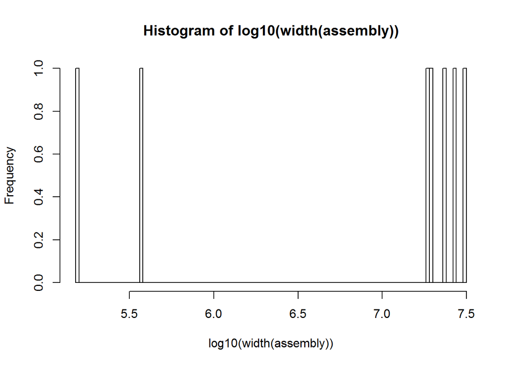

```r
hist(log10( width(assembly)), 100)
```

```r
unlist(assembly)
```

```
##   119667750-letter "DNAString" instance
## seq: CCCTAAACCCTAAACCCTAAACCCTAAACCTCTG...CATTCTTATCGCAGAATGGAAACAAACCGGATT
```

## Manipulate assembly object:

### Subset [[ ]]

```r
largest.contig = assembly[[ which(width(assembly)==max(width(assembly))) ]]
largest.contig
```

```
##   30427671-letter "DNAString" instance
## seq: CCCTAAACCCTAAACCCTAAACCCTAAACCTCTG...TAGGGTTTAGGGTTTAGGGTTTAGGGTTTAGGG
```

### Subset [ i ]

```r
top.contigs = assembly[order(width(assembly),decreasing=TRUE)][1:5]
top.contigs
```

```
##   A DNAStringSet instance of length 5
##        width seq                                       names
## [1] 30427671 CCCTAAACCCTAAACCCTA...TAGGGTTTAGGGTTTAGGG Chr1
## [2] 26975502 TATACCATGTACCCTCAAC...GATTTAGGGTTTTTAGATC Chr5
## [3] 23459830 NNNNNNNNNNNNNNNNNNN...AACCCTAAACCCTAAACCC Chr3
## [4] 19698289 NNNNNNNNNNNNNNNNNNN...TAGGGTTTAGGGTTTAGGG Chr2
## [5] 18585056 NNNNNNNNNNNNNNNNNNN...TTAGGGTTTAGGGTTTAGG Chr4
```

### names

```r
head( names(assembly) )
```

```
## [1] "Chr1" "Chr2" "Chr3" "Chr4" "Chr5" "ChrC"
```

### Subset [boolean]

```r
subsetChrC =  assembly[grepl( "ChrC",names(assembly) )]
writeXStringSet(subsetChrC, file="DATA/subsetChrC.fasta", width=80)
```

### Subset names

```r
assembly["Chr1"]
```

```
##   A DNAStringSet instance of length 1
##        width seq                                       names
## [1] 30427671 CCCTAAACCCTAAACCCTA...TAGGGTTTAGGGTTTAGGG Chr1
```

### subseq

```r
subseq(assembly,start=1,end=10)
```

```
##   A DNAStringSet instance of length 7
##     width seq                                          names
## [1]    10 CCCTAAACCC                                   Chr1
## [2]    10 NNNNNNNNNN                                   Chr2
## [3]    10 NNNNNNNNNN                                   Chr3
## [4]    10 NNNNNNNNNN                                   Chr4
## [5]    10 TATACCATGT                                   Chr5
## [6]    10 ATGGGCGAAC                                   ChrC
## [7]    10 GGATCCGTTC                                   ChrM
```

### nucleotide Content

```r
head( alphabetFrequency(assembly) )
```

```
##            A       C       G       T  M  R   W  S  Y  K V H D B      N - +
## [1,] 9709674 5435374 5421151 9697113 76 36 124 30 82 53 0 0 0 0 163958 0 0
## [2,] 6315641 3542973 3520766 6316348  5  7  18  3 12 10 0 0 0 0   2506 0 0
## [3,] 7484757 4258333 4262704 7448059  2  4   2  1  2  0 0 0 0 0   5966 0 0
## [4,] 5940546 3371349 3356091 5914038  1  0   0  0  0  0 0 0 1 0   3030 0 0
## [5,] 8621974 4832253 4858759 8652238  0  0   0  0  0  0 0 0 0 0  10278 0 0
## [6,]   48546   28496   27570   49866  0  0   0  0  0  0 0 0 0 0      0 0 0
##      .
## [1,] 0
## [2,] 0
## [3,] 0
## [4,] 0
## [5,] 0
## [6,] 0
```

### letterFrequency: e.g. GC content

```r
head( alphabetFrequency(assembly) )
```

```
##            A       C       G       T  M  R   W  S  Y  K V H D B      N - +
## [1,] 9709674 5435374 5421151 9697113 76 36 124 30 82 53 0 0 0 0 163958 0 0
## [2,] 6315641 3542973 3520766 6316348  5  7  18  3 12 10 0 0 0 0   2506 0 0
## [3,] 7484757 4258333 4262704 7448059  2  4   2  1  2  0 0 0 0 0   5966 0 0
## [4,] 5940546 3371349 3356091 5914038  1  0   0  0  0  0 0 0 1 0   3030 0 0
## [5,] 8621974 4832253 4858759 8652238  0  0   0  0  0  0 0 0 0 0  10278 0 0
## [6,]   48546   28496   27570   49866  0  0   0  0  0  0 0 0 0 0      0 0 0
##      .
## [1,] 0
## [2,] 0
## [3,] 0
## [4,] 0
## [5,] 0
## [6,] 0
```

```r
head(letterFrequency(assembly,letters=c("GC")) / width(assembly))
```

```
##            G|C
## [1,] 0.3567978
## [2,] 0.3585966
## [3,] 0.3632182
## [4,] 0.3619812
## [5,] 0.3592523
## [6,] 0.3629384
```

### sliding window frequency content (take some times)

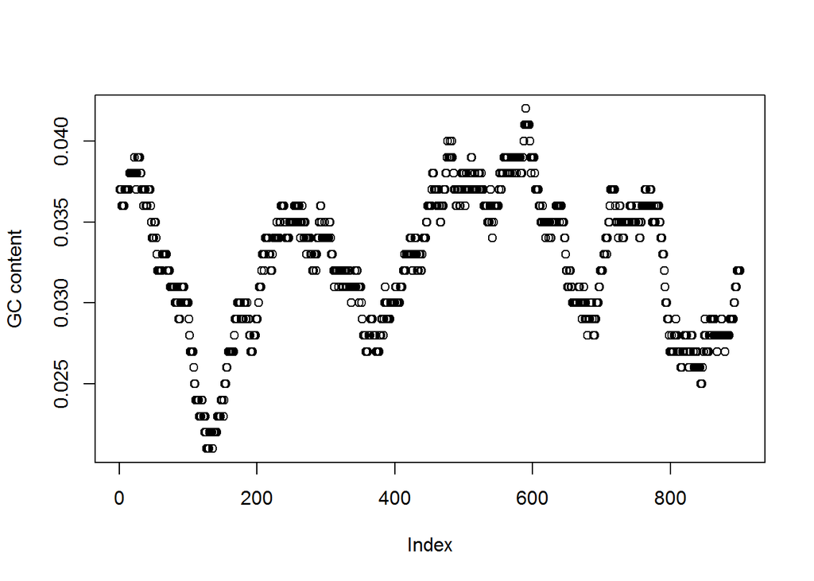

```r
plot(letterFrequencyInSlidingView(subseq(largest.contig,start=1,end=1000) , view.width=100, c("GC"))[,1] / 1000,ylab="GC content")
```

### dinucl. freqs and oligonucleotide frequency (count k-mers!)

```r
head(dinucleotideFrequency(assembly) )
```

```
##           AA      AC      AG      AT      CA      CC     CG      CT
## [1,] 3519618 1588222 1794832 2806938 1923828 1016043 697370 1798103
## [2,] 2291425 1029112 1160656 1834436 1246761  672298 457572 1166332
## [3,] 2697321 1228425 1405657 2153326 1498572  804346 559031 1396363
## [4,] 2143949  980396 1109024 1707177 1184075  637230 439585 1110456
## [5,] 3123300 1402697 1598876 2497091 1702804  901933 630299 1597206
## [6,]   17908    6721    8406   15511    8159    6901   4639    8796
##           GA     GC      GG      GT      TA      TC      TG      TT
## [1,] 1930175 902333 1008853 1579773 2336000 1928742 1920078 3512237
## [2,] 1249470 584685  660361 1026240 1527965 1256872 1242169 2289325
## [3,] 1516523 714673  805350 1226145 1772312 1510873 1492648 2672201
## [4,] 1195081 560353  630133  970522 1417439 1193369 1177345 2125882
## [5,] 1731020 803651  909379 1414706 2064837 1723961 1720200 3143216
## [6,]    9819   4474    6351    6926   12659   10400    8174   18633
```

```r
head(oligonucleotideFrequency(assembly,width = 5) )
```

```
##       AAAAA AAAAC AAAAG  AAAAT AAACA AAACC AAACG AAACT AAAGA AAAGC AAAGG
## [1,] 205544 91860 84424 134552 94382 56055 27954 69283 92900 41182 38159
## [2,] 136637 59561 55449  89124 60510 33690 17891 45225 60497 26195 25147
## [3,] 157744 69947 66624 100808 70753 39959 21826 52979 72604 31306 30688
## [4,] 123123 56124 51255  80489 57034 33390 17228 42802 56696 25540 23567
## [5,] 184244 81767 76044 119343 82386 46311 24922 61718 82901 37165 34569
## [6,]   1565   295   552    731   235   200   132   217   532   178   284
##      AAAGT  AAATA AAATC AAATG  AAATT AACAA AACAC AACAG AACAT AACCA AACCC
## [1,] 59035 102963 70011 67405 108140 95971 39397 35820 63175 49630 26216
## [2,] 38686  69302 45418 42946  70864 62594 24182 21995 41171 32472 15438
## [3,] 45617  78209 53403 49987  81195 73647 28818 27444 48327 38163 18424
## [4,] 35832  62687 42355 40079  64850 58206 23509 21855 38366 30752 15445
## [5,] 52414  91595 61741 58700  96922 85065 32739 31125 55744 43879 20770
## [6,]   243    685   376   316    577   306    70   121   175   218   160
##      AACCG AACCT AACGA AACGC AACGG AACGT AACTA AACTC AACTG AACTT  AAGAA
```

[output cut: 643 more lines]

```r
head(oligonucleotideFrequency(assembly,width = 6) )
```

```
##      AAAAAA AAAAAC AAAAAG AAAAAT AAAACA AAAACC AAAACG AAAACT AAAAGA AAAAGC
## [1,]  96046  31076  31283  47139  37141  18916  10700  25103  34585  13611
## [2,]  63657  20632  20332  32015  24409  11742   6838  16571  22777   8876
## [3,]  73794  23951  24642  35355  28503  14121   8278  19045  27077  10597
## [4,]  57177  19097  18612  28237  22653  11206   6668  15597  20859   8469
## [5,]  85858  28379  27846  42159  33301  16342   9472  22652  30683  12658
## [6,]    810    121    298    336     81     76     44     94    233     74
##      AAAAGG AAAAGT AAAATA AAAATC AAAATG AAAATT AAACAA AAACAC AAACAG AAACAT
## [1,]  14646  21582  43376  25888  26253  39035  38365  16629  14537  24850
## [2,]   9516  14280  29417  17206  16695  25806  25634   9680   8808  16388
## [3,]  12051  16899  32827  19746  19030  29205  29634  11363  10901  18854
## [4,]   8913  13014  26280  15619  15442  23148  23597   9696   8616  15125
## [5,]  13201  19502  38661  23079  22657  34946  34585  13206  12644  21950
## [6,]    134    111    255    137    117    222    110     22     41     62
##      AAACCA AAACCC AAACCG AAACCT AAACGA AAACGC AAACGG AAACGT AAACTA AAACTC
```

[output cut: 2855 more lines]

### reverse-complement

```r
assembly.rc = reverseComplement(assembly)
assembly.rc
```

```
##   A DNAStringSet instance of length 7
##        width seq                                       names
## [1] 30427671 CCCTAAACCCTAAACCCTA...TAGGGTTTAGGGTTTAGGG Chr1
## [2] 19698289 CCCTAAACCCTAAACCCTA...NNNNNNNNNNNNNNNNNNN Chr2
## [3] 23459830 GGGTTTAGGGTTTAGGGTT...NNNNNNNNNNNNNNNNNNN Chr3
## [4] 18585056 CCTAAACCCTAAACCCTAA...NNNNNNNNNNNNNNNNNNN Chr4
## [5] 26975502 GATCTAAAAACCCTAAATC...GTTGAGGGTACATGGTATA Chr5
## [6]   154478 GATGCCCGGGACCAAGTTA...ATTCCCGTCGTTCGCCCAT ChrC
## [7]   366924 AATCCGGTTTGTTTCCATT...ACCTGTTTCGAACGGATCC ChrM
```

### duplicated

```r
duplicated(assembly[c(1,3)])
```

```
## [1] FALSE FALSE
```

### unique to remove duplicates

```r
unique(assembly[c(1,3)])
```

```
##   A DNAStringSet instance of length 2
##        width seq                                       names
## [1] 30427671 CCCTAAACCCTAAACCCTA...TAGGGTTTAGGGTTTAGGG Chr1
## [2] 23459830 NNNNNNNNNNNNNNNNNNN...AACCCTAAACCCTAAACCC Chr3
```

# Manipulate fastQ file

## Install ShortRead package:

```r
source("http://bioconductor.org/biocLite.R")
biocLite("ShortRead")
```

## Load library

```r
library(ShortRead )
```

## Read the FastQ file and create a ShortReadQ file

```r
fq <- readFastq("DATA/SRR031724_1_subset.fastq")
fq
```

```
## class: ShortReadQ
## length: 1000000 reads; width: 37 cycles
```

## CountLines in a fastQ file;

```r
countLines("DATA/SRR031724_1_subset.fastq")
```

```
## SRR031724_1_subset.fastq
##                  4000000
```

### Inspect the first three reads : sequence, quality, id

```r
head(sread(fq), 3)
```

```
##   A DNAStringSet instance of length 3
##     width seq
## [1]    37 GTTTTGTCCAAGTTCTGGTAGCTGAATCCTGGGGCGC
## [2]    37 GTTGTCGCATTCCTTACTCTCATTCGGGAATTCTGTT
## [3]    37 GAATTTTTTGAGAGCGAAATGATAGCCGATGCCCTGA
```

```r
head(quality(fq), 3)
```

```
## class: FastqQuality
## quality:
##   A BStringSet instance of length 3
##     width seq
## [1]    37 IIIIIIIIIIIIIIIIIIIIIIIIIIII+HIIII<IE
## [2]    37 IIIIIIIIIIIIIIIIIIIIIIIIIIIIIIIIIIIII
## [3]    37 IIIIIIIIIIIIIIIIIIIIII'IIIIIGBIIII2I+
```

```r
head(id(fq), 3)
```

```
##   A BStringSet instance of length 3
##     width seq
## [1]    58 SRR031724.1 HWI-EAS299_4_30M2BAAXX:5:1:1513:1024 length=37
## [2]    57 SRR031724.2 HWI-EAS299_4_30M2BAAXX:5:1:937:1157 length=37
## [3]    58 SRR031724.4 HWI-EAS299_4_30M2BAAXX:5:1:1443:1122 length=37
```

### Example of report generated with Bioconductor: the code is not provided (more advanced) this report gives interesting information about the QC of fastQ file

```r
browseURL("DATA/GSM461176_81_qa_report/index.html")
```

### GC content:

```r
alf0 <- alphabetFrequency(sread(fq), as.prob=TRUE, collapse=TRUE)
sum(alf0[c("G", "C")])
```

```
## [1] 0.5457237
```

### Alphabet by cycle:

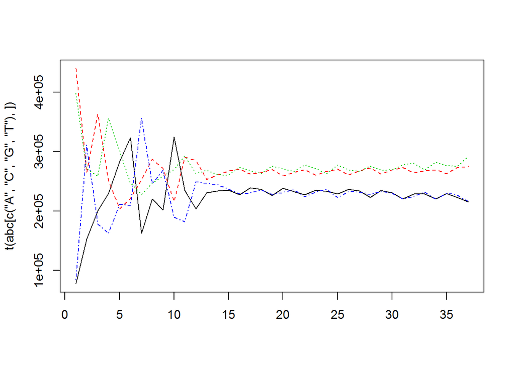

```r
abc <- alphabetByCycle(sread(fq))
matplot(t(abc[c("A", "C", "G", "T"),]), type="l")
```

### Adaptor trimming

```r
head(sread(fq), 3)
```

```
##   A DNAStringSet instance of length 3
##     width seq
## [1]    37 GTTTTGTCCAAGTTCTGGTAGCTGAATCCTGGGGCGC
## [2]    37 GTTGTCGCATTCCTTACTCTCATTCGGGAATTCTGTT
## [3]    37 GAATTTTTTGAGAGCGAAATGATAGCCGATGCCCTGA
```

```r
fqtrim <- trimLRPatterns(Lpattern="GTT", subject=fq)
sread(fqtrim)[1:2]
```

```
##   A DNAStringSet instance of length 2
##     width seq
## [1]    34 TTGTCCAAGTTCTGGTAGCTGAATCCTGGGGCGC
## [2]    34 GTCGCATTCCTTACTCTCATTCGGGAATTCTGTT
```